# LegumeWeight

Prepared by Loretta Clancy

### Data Definitions:

‘**Rhizobes**’, i.e. bacteria living on plant roots, can increase plant growth. This dataset investigates the effect of different rhizobial strains on legume growth. Variable are as follows:

**Block**: independent experimental ‘block’

**Plant**: plant species (Ad: Acacia dealbata; Am: Acacia mearnsii; Dm: Daviesia mimosoides; Gc: Glycine clandestina; Hv: Hardenbergia violacea; Oe: Oxylobium ellipticum)

**Strain**: rhizobial strain (note: values are descriptive strain identifiers, not quantitative measures)

**Weight**: plant weight at conclusion of experiment.

```r
library(tidyverse)
legumeData <- read_csv("../data/legume_weights_rhizobia_20str.csv")
str(legumeData)
```

```
## Classes 'tbl_df', 'tbl' and 'data.frame':    1200 obs. of  4 variables:
##  $ Block : chr  "A" "B" "C" "D" ...
##  $ Plant : chr  "Ad" "Ad" "Ad" "Ad" ...
##  $ Strain: int  1075 1075 1075 1075 1075 1075 1075 1075 1075 1075 ...
##  $ weight: num  3.27 1.85 3.36 1.92 2.17 2.53 2.44 2.05 2.37 0.81 ...
##  - attr(*, "spec")=List of 2
##   ..$ cols   :List of 4
##   .. ..$ Block : list()
##   .. .. ..- attr(*, "class")= chr  "collector_character" "collector"
##   .. ..$ Plant : list()
##   .. .. ..- attr(*, "class")= chr  "collector_character" "collector"
##   .. ..$ Strain: list()
##   .. .. ..- attr(*, "class")= chr  "collector_integer" "collector"
##   .. ..$ weight: list()
##   .. .. ..- attr(*, "class")= chr  "collector_double" "collector"
##   ..$ default: list()
##   .. ..- attr(*, "class")= chr  "collector_guess" "collector"
##   ..- attr(*, "class")= chr "col_spec"
```

Certain columns should be made into factors (as character)

```r
legumeData$Strain <- as.character(legumeData$Strain)
str(legumeData)
```

```
## Classes 'tbl_df', 'tbl' and 'data.frame':    1200 obs. of  4 variables:
##  $ Block : chr  "A" "B" "C" "D" ...
##  $ Plant : chr  "Ad" "Ad" "Ad" "Ad" ...
##  $ Strain: chr  "1075" "1075" "1075" "1075" ...
##  $ weight: num  3.27 1.85 3.36 1.92 2.17 2.53 2.44 2.05 2.37 0.81 ...
##  - attr(*, "spec")=List of 2
##   ..$ cols   :List of 4
##   .. ..$ Block : list()
##   .. .. ..- attr(*, "class")= chr  "collector_character" "collector"
##   .. ..$ Plant : list()
##   .. .. ..- attr(*, "class")= chr  "collector_character" "collector"
##   .. ..$ Strain: list()
##   .. .. ..- attr(*, "class")= chr  "collector_integer" "collector"
##   .. ..$ weight: list()
##   .. .. ..- attr(*, "class")= chr  "collector_double" "collector"
##   ..$ default: list()
##   .. ..- attr(*, "class")= chr  "collector_guess" "collector"
##   ..- attr(*, "class")= chr "col_spec"
```

These are defined here so that they can be used down below. Note: Actual names have a line break in them

```r
plantNames <- list('Ad'="Acacia\ndealbata",
                   'Am'="Acacia\nmearnsii",
                   'Dm'="Daviesia\nmimosoides",
                   'Gc'="Glycine\nclandestina",
                   'Hv'="Hardenbergia\nviolacea",
                   'Oe'="Oxylobium\nellipticum"
                   )
plantLabeller <- function(variable,value){
  return(plantNames[value])
}
```

I am not sure of any requirement to ‘tidy’ this data any further …. will look at this later if necessary

and I recall from discussions that “Block” is of no consequence to this analysis (classroom discussion), so need to remember this.

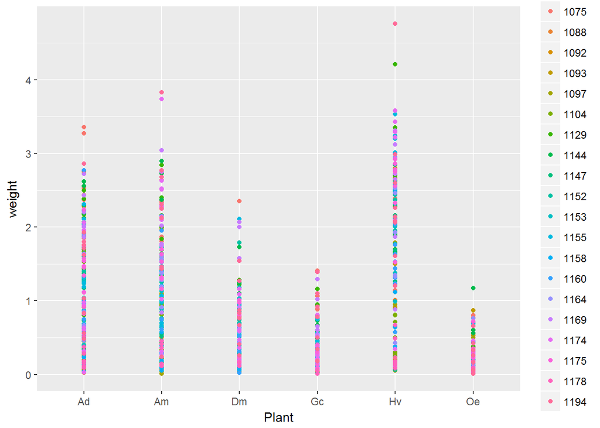

```r
ggplot(legumeData, aes(x=Plant, y=weight, colour=Strain)) +
    geom_point()
```

```r
sum(is.na(legumeData$weight))
```

```
## [1] 295
```

We will filter them out

```r
legumeData <- legumeData %>%
    filter(!is.na(legumeData$weight))
```

How many Plants, Strains are there

```r
legumeData %>% select(Plant) %>% distinct()
```

```
## # A tibble: 6 x 1
##   Plant
##   <chr>
## 1 Ad
## 2 Am
## 3 Dm
## 4 Gc
## 5 Hv
## 6 Oe
```

```r
legumeData %>% select(Strain) %>% distinct()
```

```
## # A tibble: 20 x 1
##    Strain
##    <chr>
##  1 1075
##  2 1088
##  3 1092
##  4 1093
##  5 1097
##  6 1104
##  7 1129
##  8 1144
##  9 1147
## 10 1152
## 11 1153
## 12 1155
## 13 1158
## 14 1160
## 15 1164
## 16 1169
## 17 1174
## 18 1175
## 19 1178
## 20 1194
```

The above chart doesn’t really tell me much, need to try a different view

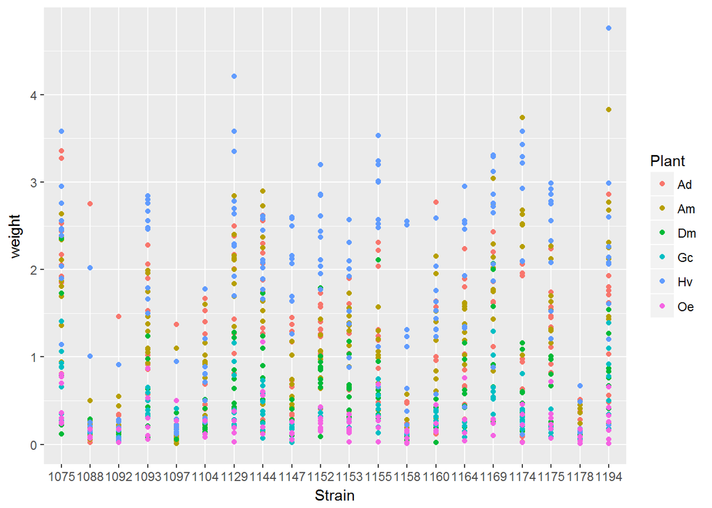

```r
ggplot(legumeData, aes(x=Strain, y=weight, colour=Plant)) +
    geom_point()
```

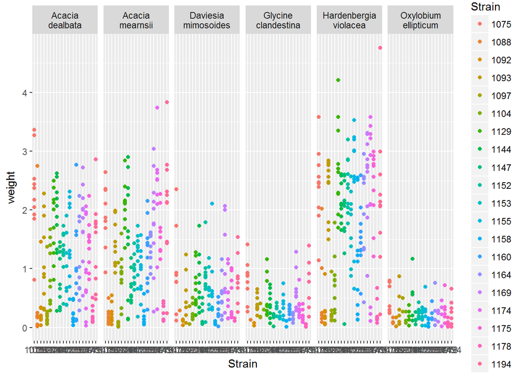

```r
ggplot(legumeData, aes(x=Strain, y=weight, colour=Strain)) +
    geom_point() +
    facet_grid(~Plant, labeller = plantLabeller)
```

## Question: Does every plant have every strain?

```r
data.frame(table(legumeData$Plant))
```

```
##   Var1 Freq
## 1   Ad  187
## 2   Am  184
## 3   Dm  131
## 4   Gc  117
## 5   Hv  188
## 6   Oe   98
```

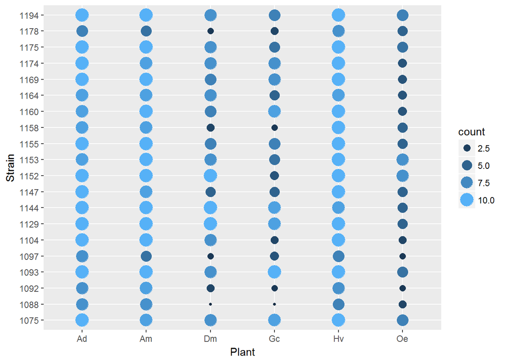

```r
checkData <- legumeData %>%
    group_by(Plant, Strain) %>%
    summarise(count=n())

ggplot(checkData, aes(x=Plant, y=Strain)) +
    geom_point(aes(colour=count, size=count)) +
    guides(colour='legend')
```

`**NOTE: Need to find out how to combine these legends into one **`

To view this in a data format:

```r
gridCheckData <- checkData %>%
    spread(key=Strain, value = count)
gridCheckData
```

```
## # A tibble: 6 x 21
## # Groups:   Plant [6]
##   Plant `1075` `1088` `1092` `1093` `1097` `1104` `1129` `1144` `1147`
##   <chr>  <int>  <int>  <int>  <int>  <int>  <int>  <int>  <int>  <int>
## 1 Ad        10      8      8     10      8     10     10     10     10
## 2 Am         9      8      9     10      6     10     10     10      9
## 3 Dm         8      1      3      8      2      8     10     10      5
## 4 Gc         9      1      2     10      4      3      9      9      5
## 5 Hv        10      7      8     10      7     10     10      9     10
## 6 Oe         7      3      2      6      2      3      5      5      5
## # ... with 11 more variables: `1152` <int>, `1153` <int>, `1155` <int>,
## #   `1158` <int>, `1160` <int>, `1164` <int>, `1169` <int>, `1174` <int>,
## #   `1175` <int>, `1178` <int>, `1194` <int>
```

The above shows that each Plant does have every Strain present, but the counts of the strains vary.

## Questions: Does the weight have any correlation with the strain for the plants?

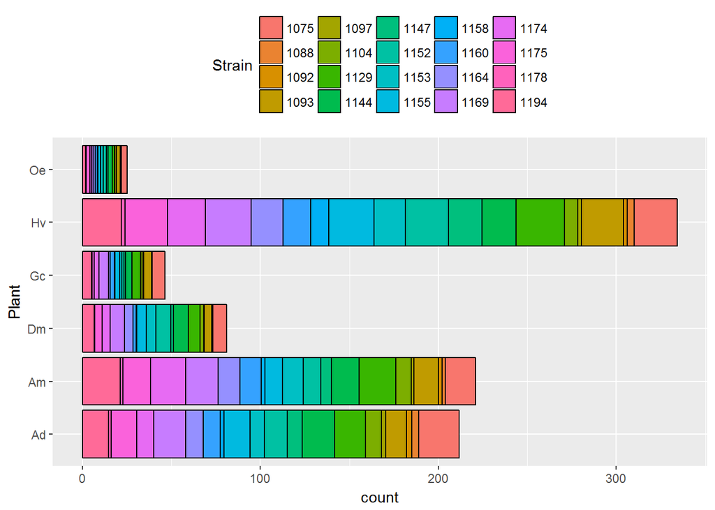

```r
ggplot(legumeData, aes(x=Plant, weight=weight), position=position_stack(reverse = TRUE)) +
    coord_flip() +
    geom_bar(aes(fill=Strain), colour="black") +
    theme(legend.position = "top")
```

Now lets have a look at the mean weights for the Strains

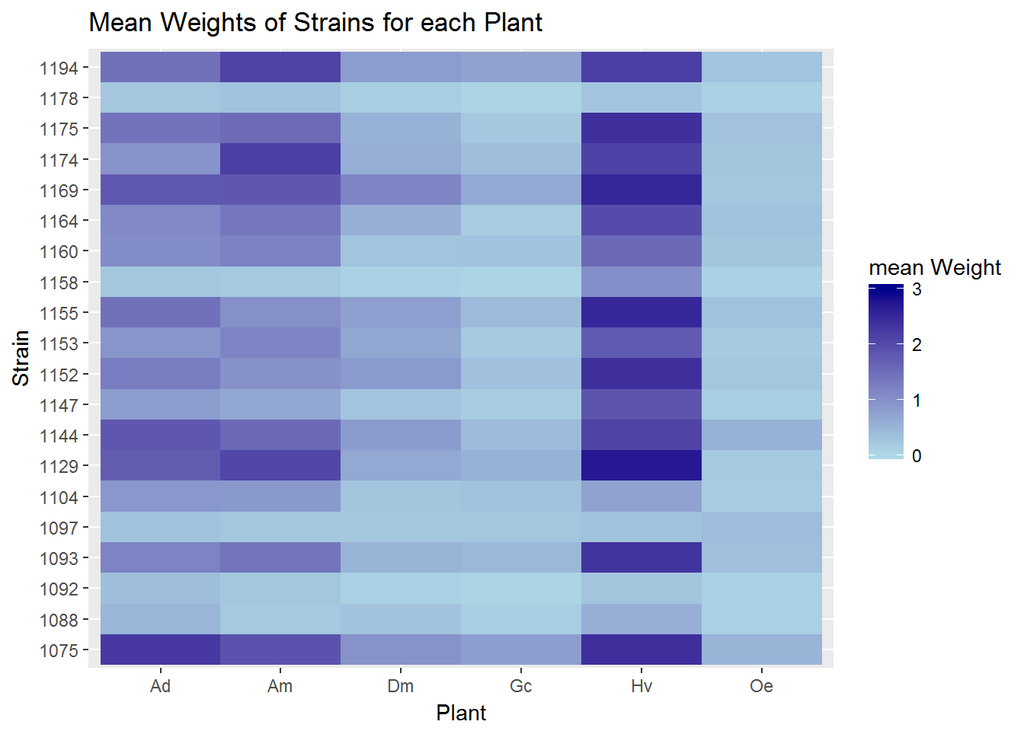

```r
checkData2 <- legumeData %>%
    group_by(Plant, Strain) %>%
    summarise(meanWeight = mean(weight))

ggplot(checkData2, aes(x=Plant, y=Strain)) +
    geom_tile(aes(fill=meanWeight)) +
    scale_fill_gradient(low="LightBlue", high="DarkBlue", limits=c(0, 3)) +
    labs(title = "Mean Weights of Strains for each Plant", fill="mean Weight")
```

Is this easier to read than

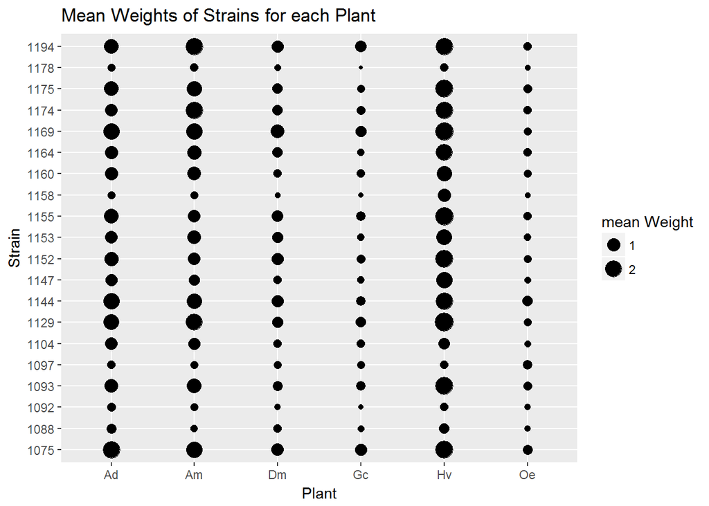

```r
ggplot(checkData2, aes(x=Plant, y=Strain, size=meanWeight)) +
    geom_point() +
    labs(title = "Mean Weights of Strains for each Plant", size="mean Weight")
```

Or another alternative

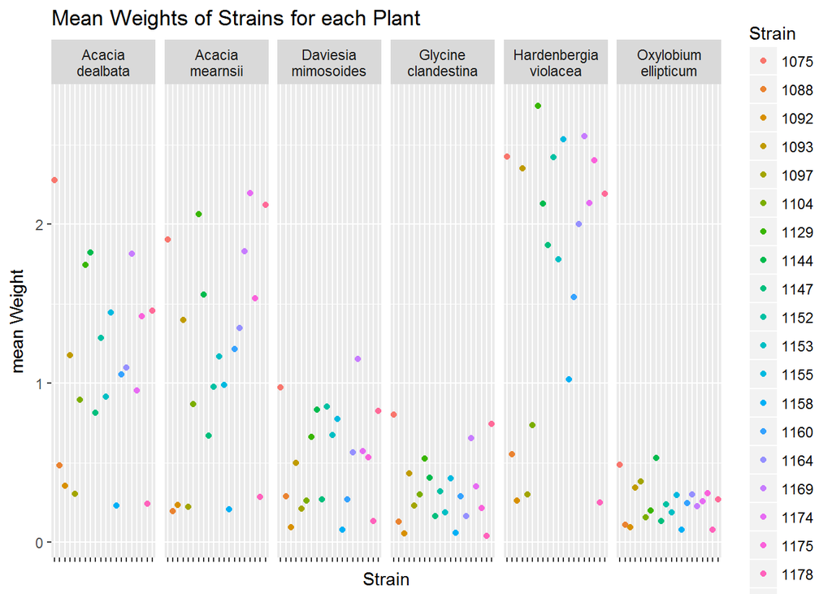

```r
ggplot(checkData2, aes(x=Strain, y=meanWeight, colour=Strain)) +
    geom_point() +
    facet_grid(~Plant, labeller=plantLabeller) +
    labs(title = "Mean Weights of Strains for each Plant",
         y="mean Weight") +
    theme(axis.text.x = element_blank())
```